COMS W4111: Introduction to Databases  
Section 002, Fall 2021

Homework 3A

# Overview

- To smooth the time students spend on homework per week, we split each of HW 3 and HW 4 into two parts: A, B.
- HW 3A is worth 8 points out of the semesters 100 total possible points.
- HW 3A is common to both the programming and non-programming tracks. HW 3A requires importing and transforming data for MySQL, MongoDB and Neo4j databases. Subsequent HW projects will use the processed data.

| **HW 3A Concept** |
| --- |

- HW 3A has two sources of raw data input files:
  - CSV data downloaded from [IMDB.](https://www.imdb.com/interfaces/)
  - JSON data files from Jeffrey Lancaster's Game-of-Thrones [visualization project.](https://jeffreylancaster.github.io/game-of-thrones/)
- We have downloaded, simplified and reduced the size and complexity of some of the data to make the assignment easier and to require less powerful computing resources.
- In HW 3A, you will process the raw data to produce well-design data models and data in MySQL, Neo4j and MongoDB. The final data model:
  - Contains core information in MySQL.
  - Document and hierarchical information in MongoDB.
  - Graph data describing relationships between characters and actors in IMDB.
- The HW 3A submission format is a copy of this notebook with each of the tasks completed. Completing a specific task involves:
  - Creating a "to be" schema.
  - Populating with data by extract-transform-load of the raw data.
  - Providing the queries and code you use to perform the schema creation and transformation.
  - Providing test queries that show the structure of the resulting data and schema.

This homework will be due $\textbf{Monday, November 22, 2021 at midnight}$.

# Environment Setup

## Installation

- You must install and set up.
  - [Neo4j Desktop](https://neo4j.com/download-neo4j-now/): This includes configuring and using the sample movie graph to test your configuration: `:play movie graph`. (https://neo4j.com/developer/neo4j-browser/)
  - [MongoDB Community Edition](https://docs.mongodb.com/manual/installation/)
  - [MongoDB Compass](https://docs.mongodb.com/compass/current/install/)
- Create two new MySQL schema/databases: `HW3_IMDBRaw` and `HW3_IMDBFixed.`

## Test Setup

### Neo4j

- Using Neo4j, create a new project `HW3` and create a graph in the project. **Remember the DB password you choose.**
- Start and connect to the graph using the Neo4j browser (launch-able from `Open` on the desktop after you create the graph).
- Enter `:play movie graph` in the Cypher command area in the UI and follow the tutorial instructions.
- After completion, run the query

```
match (n1:Person {name: "Madonna"})-[r1:ACTED_IN]-(m)-[r2:DIRECTED]-(n2), (m)-[r3:ACTED_IN]-(n3), (m3)-[r4:DIRECTED]-(n3) return n1,r1,m,r2,n2,r3,n3,r4,m3
```

- Capture the result, save to a file and embed the file below. You answer should be:

[figure not shown]

```python
!pip install py2neo
```

- Using the credentials you defined when creating the Neo4j project and graph, test your ability to connect to the graph.
- There is an [on-line tutorial](https://medium.com/@technologydata25/connect-neo4j-to-jupyter-notebook-c178f716d6d5) that may help.

```python
from py2neo import Graph,Node,Relationship
```

```python
#
# The bolt URL and neo4j should be the same for everyone.
# Replace dbuserdbuser with the passsword you set when creating the graph.
#
graph = Graph("bolt://localhost:7687", auth=("neo4j", "admin123"))
```

```python
#
# The following is the query you entered above.
#
q = """match (n1:Person {name: "Madonna"})-[r1:ACTED_IN]-(m)-[r2:DIRECTED]-(n2),
        (m)-[r3:ACTED_IN]-(n3), (m3)-[r4:DIRECTED]-(n3)
        return n1,r1,m,r2,n2,r3,n3,r4,m3"""
```

```python
#
# Run the query.
#
result=graph.run(q)
```

```python
for r in result:
    for x in r:
        print(type(x), ":", dict(x))
```

```
<class 'py2neo.data.Node'> : {'name': 'Madonna', 'born': 1954}
<class 'py2neo.data.ACTED_IN'> : {'roles': ['"All the Way" Mae Mordabito']}
<class 'py2neo.data.Node'> : {'tagline': 'Once in a lifetime you get a chance to do something different.', 'title': 'A League of Their Own', 'released': 1992}
<class 'py2neo.data.DIRECTED'> : {}
<class 'py2neo.data.Node'> : {'name': 'Penny Marshall', 'born': 1943}
<class 'py2neo.data.ACTED_IN'> : {'roles': ['Jimmy Dugan']}
<class 'py2neo.data.Node'> : {'name': 'Tom Hanks', 'born': 1956}
<class 'py2neo.data.DIRECTED'> : {}
<class 'py2neo.data.Node'> : {'tagline': 'In every life there comes a time when that thing you dream becomes that thing you do', 'title': 'That Thing You Do', 'released': 1996}
```

## MongoDB and Compass

- Run the code snippet below to load the raw information about characters in Game of Thrones.

```python
import json
```

```python
with open('./characters.json', "r") as in_file:
    c_data = json.load(in_file)
c_data = c_data['characters']
```

```python
c_data[1]
```

```
{'characterName': 'Aegon Targaryen',
 'houseName': 'Targaryen',
 'royal': True,
 'parents': ['Elia Martell', 'Rhaegar Targaryen'],
 'siblings': ['Rhaenys Targaryen', 'Jon Snow'],
 'killedBy': ['Gregor Clegane']}
```

```python
#
# Connect to MongoDB
#
from pymongo import MongoClient
client = MongoClient(
                host="localhost",
                port=27017
            )
client
```

```
MongoClient(host=['localhost:27017'], document_class=dict, tz_aware=False, connect=True)
```

```python
#
# Load the character information into the HW3 MongoDB and collection
#
for c in c_data:
    client.HW3.GOT_Characters.insert_one(c)
```

```python
#
# Now, test for correct loading.
#
f = {"siblings": "Sansa Stark"}
p = {
    "_id": 0,
    "characterName": 1,
    "characterImageFull": 1,
    "actorName": 1
}
```

```python
result = client.HW3.GOT_Characters.find(f, p)
result = list(result)
```

```python
for r in result:
    print(json.dumps(r, indent=2))
```

```
{
  "characterName": "Arya Stark",
  "characterImageFull": "https://images-na.ssl-images-amazon.com/images/M/MV5BMTk5MTYwNDc0OF5BMl5BanBnXkFtZTcwOTg2NDg1Nw@@._V1_SY1000_CR0,0,665,1000_AL_.jpg",
  "actorName": "Maisie Williams"
}
{
  "characterName": "Bran Stark",
  "characterImageFull": "https://images-na.ssl-images-amazon.com/images/M/MV5BMTA1NTg0NTI3MTBeQTJeQWpwZ15BbWU3MDEyNjg4OTQ@._V1_SX1500_CR0,0,1500,999_AL_.jpg",
  "actorName": "Isaac Hempstead Wright"
}
{
  "characterName": "Rickon Stark",
  "characterImageFull": "https://images-na.ssl-images-amazon.com/images/M/MV5BMWZiOGNjMDAtOTRlNi00MDJmLWEyMTMtOGEwZTM5ODJlNDAyXkEyXkFqcGdeQXVyMjk3NTUyOTc@._V1_.jpg",
  "actorName": "Art Parkinson"
}
{
  "characterName": "Robb Stark",
  "characterImageFull": "https://images-na.ssl-images-amazon.com/images/M/MV5BMjI2NDE1NzczNF5BMl5BanBnXkFtZTcwNjcwODg4OQ@@._V1_SY1000_CR0,0,845,1000_AL_.jpg",
  "actorName": "Richard Madden"
}
```

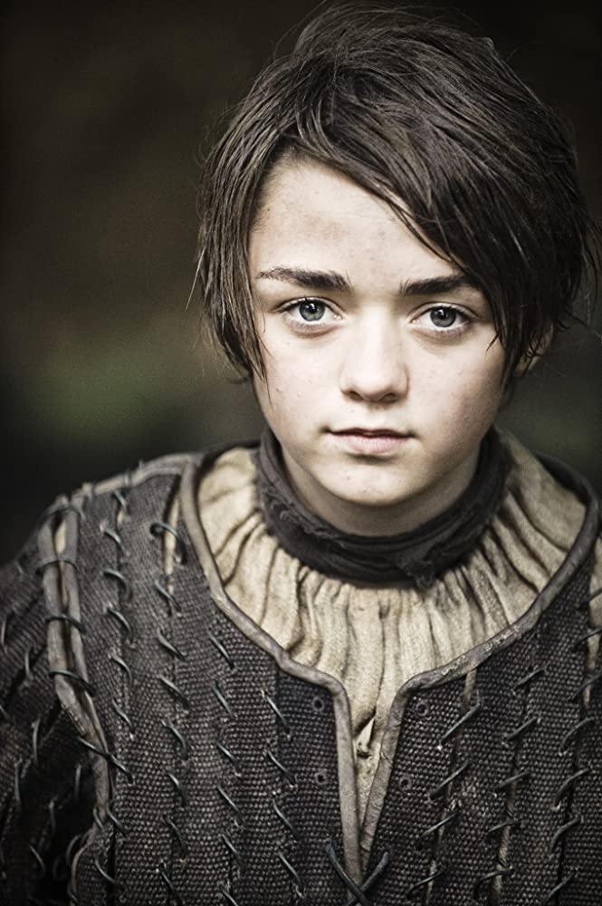

```python
#
# And, just for the heck of it ...
#
from IPython import display
display.Image(result[0]["characterImageFull"], width="300px")
```

```python
#!pip install nameparser
```

```python
from nameparser import HumanName
```

```python
from pymongo import MongoClient
import json
import pandas as pd
```

```python
from sqlalchemy import create_engine
```

```python
engine = create_engine("mysql+pymysql://root:admin123@localhost")
```

```python
client = MongoClient(
                host="localhost",
                port=27017
            )
```

```python
client.list_database_names()
```

```
['HW3', 'admin', 'config', 'local']
```

# Task I: Essential Game of Thrones Character and Actor Information

## Task I-a: Load Raw Information

- Character documents in the collection `GOT_Characters` have several fields.
- The first task is to get the essential fields and then load info a core MySQL table.
- The core fields are:
  - actorLink
  - actorName
  - characterName
  - characterLink
  - characterImageFull
  - characterImageThumb
  - houseName
  - kingsguard
  - nickname
  - royal
- This requires a simple `find` call to MongoDB.
- **Question:** Put your code here.

```python
result = client.HW3.GOT_Characters.find()
```

- Execute the following test.

```python
result = list(result)
for r in result:
    r["id"] = str(r["_id"])
    del r["_id"]
result[10]
```

```
{'characterName': 'Archmaester Marwyn',
 'characterLink': '/character/ch0578265/',
 'actorName': 'Jim Broadbent',
 'actorLink': '/name/nm0000980/',
 'id': '619acf930551f2986f847123'}
```

- **Question:** Create a table in `HW3_IMDBRaw` to hold the `characters` information. Show you create table statement, your code for loading the table and a test query below. You may use the `%sql` extension. You may also use `pandas.`

```python
data = pd.DataFrame.from_dict(result)
```

```python
data = data[['id', 'characterName', 'characterLink','actorName', 'actorLink', 'characterImageFull', 'characterImageThumb', 'kingsguard', 'nickname', 'royal']]
```

```python
data = data.drop('houseName', axis=1)
```

```python
data.head()
```

|  | id | characterName | characterLink | actorName | actorLink | characterImageFull | characterImageThumb | kingsguard | nickname | royal |
| --- | --- | --- | --- | --- | --- | --- | --- | --- | --- | --- |
| 0 | 619acf930551f2986f847119 | Addam Marbrand | /character/ch0305333/ | B.J. Hogg | /name/nm0389698/ | NaN | NaN | NaN | NaN | NaN |
| 1 | 619acf930551f2986f84711a | Aegon Targaryen | NaN | NaN | NaN | NaN | NaN | NaN | NaN | True |
| 2 | 619acf930551f2986f84711b | Aeron Greyjoy | /character/ch0540081/ | Michael Feast | /name/nm0269923/ | https://images-na.ssl-images-amazon.com/images... | https://images-na.ssl-images-amazon.com/images... | NaN | Damphair | NaN |
| 3 | 619acf930551f2986f84711c | Aerys II Targaryen | /character/ch0541362/ | David Rintoul | /name/nm0727778/ | https://images-na.ssl-images-amazon.com/images... | https://images-na.ssl-images-amazon.com/images... | NaN | The Mad King | True |
| 4 | 619acf930551f2986f84711d | Akho | /character/ch0544520/ | Chuku Modu | /name/nm6729880/ | https://images-na.ssl-images-amazon.com/images... | https://images-na.ssl-images-amazon.com/images... | NaN | NaN | NaN |

```python
from sqlalchemy import create_engine
db_data = 'mysql+pymysql://' + 'root' + ':' + 'admin123' + '@' + 'localhost' + ':'+ str(3306)
engine = create_engine(db_data)
#engine = create_engine("mysql+pymysql://root:admin123@localhost")
data.to_sql("characters", engine, schema="HW3_GOT_Raw", if_exists='replace', index=False)
```

- Test your result with the query below.

```python
pd.read_sql_query("select * from HW3_GOT_Raw.characters limit 10;", engine)
```

|  | id | characterName | characterLink | actorName | actorLink | characterImageFull | characterImageThumb | kingsguard | nickname | royal |
| --- | --- | --- | --- | --- | --- | --- | --- | --- | --- | --- |
| 0 | 619acf930551f2986f847119 | Addam Marbrand | /character/ch0305333/ | B.J. Hogg | /name/nm0389698/ | None | None | None | None | NaN |
| 1 | 619acf930551f2986f84711a | Aegon Targaryen | None | None | None | None | None | None | None | 1.0 |
| 2 | 619acf930551f2986f84711b | Aeron Greyjoy | /character/ch0540081/ | Michael Feast | /name/nm0269923/ | https://images-na.ssl-images-amazon.com/images... | https://images-na.ssl-images-amazon.com/images... | None | Damphair | NaN |
| 3 | 619acf930551f2986f84711c | Aerys II Targaryen | /character/ch0541362/ | David Rintoul | /name/nm0727778/ | https://images-na.ssl-images-amazon.com/images... | https://images-na.ssl-images-amazon.com/images... | None | The Mad King | 1.0 |
| 4 | 619acf930551f2986f84711d | Akho | /character/ch0544520/ | Chuku Modu | /name/nm6729880/ | https://images-na.ssl-images-amazon.com/images... | https://images-na.ssl-images-amazon.com/images... | None | None | NaN |
| 5 | 619acf930551f2986f84711e | Alliser Thorne | /character/ch0246938/ | Owen Teale | /name/nm0853583/ | https://images-na.ssl-images-amazon.com/images... | https://images-na.ssl-images-amazon.com/images... | None | None | NaN |
| 6 | 619acf930551f2986f84711f | Alton Lannister | /character/ch0305012/ | Karl Davies | /name/nm0203801/ | https://images-na.ssl-images-amazon.com/images... | https://images-na.ssl-images-amazon.com/images... | None | None | NaN |
| 7 | 619acf930551f2986f847120 | Alys Karstark | /character/ch0576836/ | Megan Parkinson | /name/nm8257864/ | None | None | None | None | NaN |
| 8 | 619acf930551f2986f847121 | Amory Lorch | /character/ch0305002/ | Fintan McKeown | /name/nm0571654/ | https://images-na.ssl-images-amazon.com/images... | https://images-na.ssl-images-amazon.com/images... | None | None | NaN |
| 9 | 619acf930551f2986f847122 | Anguy | /character/ch0316930/ | Philip McGinley | /name/nm1528121/ | https://images-na.ssl-images-amazon.com/images... | https://images-na.ssl-images-amazon.com/images... | None | None | NaN |

## Task I-b: Improve Schema

- There are several problems with the raw characters and actors information. Some obvious examples are:
  - There are two entity types in one table: `characters` and `actors.`
  - The columns are not typed.
  - There are no keys or constraints.
  - Repeating prefixes like `/name/` is a poor design.
- Create a schema `HW3_GOT_Fixed` that has an improved schema and data model. Show your create and alter table, and data loading statements below. Also, run a query against your tables to show the data.

### Cleaning the data

The following DDL create a new schema and characters table for entering cleaned data

```
USE hw3_got_fixed;

create table characters
(
    id                  text       null,
    characterName       text       null,
    characterLink       text       null,
    actorName           text       null,
    actorLink           text       null,
    characterImageFull  text       null,
    characterImageThumb text       null,
    kingsguard          tinyint(1) null,
    nickname            text       null,
    royal               tinyint(1) null
);

-- Copy Data from raw
insert into characters
select * from hw3_got_raw.characters;

alter table characters modify id VARCHAR(50) not null;

alter table characters modify characterName VARCHAR(30) null;

alter table characters modify characterImageFull VARCHAR(200) null;

alter table characters modify characterImageThumb VARCHAR(200) null;

alter table characters modify kingsguard bool default FALSE null;

alter table characters modify royal bool default FALSE null;

alter table characters modify nickname VARCHAR(50) null;


-- Create an actor_id
alter table characters
    add actor_id VARCHAR(20) null;

UPDATE characters SET actor_id =
substr(actorLink, length('name')+3, length(actorLink) - length('name')-3)
WHERE 1;

-- Create a character_id
alter table characters
    add character_id VARCHAR(30) null;

UPDATE characters SET character_id =
substr(characterLink, length('character')+3, length(characterLink) - length('character')-3)
WHERE 1;

-- Update the kingsguard and royal columns
UPDATE characters set kingsguard = 0
where kingsguard IS NULL;

UPDATE characters set royal = 0
where royal IS NULL;
```

Ids received from the Mongo DB are used as a primary key in the characters table as the data is not cleaned and many different characters have the same name. Eg: White Walker. These should instead be White Walker #1, White Walker #2 etc. Therefore to model this data we use id.

```
alter table characters
    add constraint characters_pk
        primary key (id);
```

Currently the characters table contains actor infomration as well. We will drop actor info later. We need the information to populate data into the actors table

```python
character_data = pd.read_sql_query("select * from hw3_got_fixed.characters;", engine)
```

```python
character_data.head()
```

|  | id | characterName | characterLink | actorName | actorLink | characterImageFull | characterImageThumb | kingsguard | nickname | royal | actor_id | character_id |
| --- | --- | --- | --- | --- | --- | --- | --- | --- | --- | --- | --- | --- |
| 0 | 619acf930551f2986f847119 | Addam Marbrand | /character/ch0305333/ | B.J. Hogg | /name/nm0389698/ | None | None | NaN | None | NaN | nm0389698 | ch0305333 |
| 1 | 619acf930551f2986f84711a | Aegon Targaryen | None | None | None | None | None | NaN | None | 1.0 | None | None |
| 2 | 619acf930551f2986f84711b | Aeron Greyjoy | /character/ch0540081/ | Michael Feast | /name/nm0269923/ | https://images-na.ssl-images-amazon.com/images... | https://images-na.ssl-images-amazon.com/images... | NaN | Damphair | NaN | nm0269923 | ch0540081 |
| 3 | 619acf930551f2986f84711c | Aerys II Targaryen | /character/ch0541362/ | David Rintoul | /name/nm0727778/ | https://images-na.ssl-images-amazon.com/images... | https://images-na.ssl-images-amazon.com/images... | NaN | The Mad King | 1.0 | nm0727778 | ch0541362 |
| 4 | 619acf930551f2986f84711d | Akho | /character/ch0544520/ | Chuku Modu | /name/nm6729880/ | https://images-na.ssl-images-amazon.com/images... | https://images-na.ssl-images-amazon.com/images... | NaN | None | NaN | nm6729880 | ch0544520 |

Now we create an actors table. It has an autoincrement column (a_id) which acts as a unique value for an actor. We also create a joint character_actors table as characters and actors follow a many-to-many relationship.

```
-- Create an actors table
drop table if exists actors;
create table actors
(
    actor_id VARCHAR(20) null,
    actorName VARCHAR(100) null,
    a_id int NOT NULL AUTO_INCREMENT,
    PRIMARY KEY (a_id)
);

-- Create a character_actors table
create table characters_actors
(
    c_id VARCHAR(50) not null,
    a_id INT not null
);
```

Load data into actors using pandas. We utilise the new characters table in hw3_got_fixed as it contains the cleaned column `actor_id`

```python
actors_data = character_data[['actor_id', 'actorName']].drop_duplicates()

actors_data = actors_data.dropna()

actors_data.to_sql('actors', engine, schema="HW3_GOT_Fixed", if_exists='append', index=False)
```

```python
pd.read_sql_query("select * from hw3_got_fixed.actors LIMIT 10;", engine)
```

|  | actor_id | actorName | a_id |
| --- | --- | --- | --- |
| 0 | nm0389698 | B.J. Hogg | 1 |
| 1 | nm0269923 | Michael Feast | 2 |
| 2 | nm0727778 | David Rintoul | 3 |
| 3 | nm6729880 | Chuku Modu | 4 |
| 4 | nm0853583 | Owen Teale | 5 |
| 5 | nm0203801 | Karl Davies | 6 |
| 6 | nm8257864 | Megan Parkinson | 7 |
| 7 | nm0571654 | Fintan McKeown | 8 |
| 8 | nm1528121 | Philip McGinley | 9 |
| 9 | nm0000980 | Jim Broadbent | 10 |

```
INSERT INTO characters_actors
select t1.id as c_id, t2.a_id as a_id from
    hw3_got_fixed.characters as t1 join hw3_got_fixed.actors as t2
where
    exists
        (select * from hw3_got_fixed.characters as t3 where
            t1.id=t3.id and t2.actorName=t3.actorName);
```

```python
pd.read_sql("select * from hw3_got_fixed.characters_actors LIMIT 10;", engine)
```

|  | c_id | a_id |
| --- | --- | --- |
| 0 | 619acf930551f2986f847119 | 1 |
| 1 | 619acf930551f2986f84711b | 2 |
| 2 | 619acf930551f2986f84711c | 3 |
| 3 | 619acf930551f2986f84711d | 4 |
| 4 | 619acf930551f2986f84711e | 5 |
| 5 | 619acf930551f2986f84711f | 6 |
| 6 | 619acf930551f2986f847120 | 7 |
| 7 | 619acf930551f2986f847121 | 8 |
| 8 | 619acf930551f2986f847122 | 9 |
| 9 | 619acf930551f2986f847123 | 10 |

We now add foreign key relationships from the characters_actors tables to the respective tables.

```
alter table characters_actors
    add constraint characters_actors_actors_actor_id_fk
        foreign key (a_id) references actors (a_id);

alter table characters_actors
    add constraint characters_actors_characters_id_fk
        foreign key (c_id) references characters (id);
```

We now drop the extra information in characters table

```
alter table characters drop column characterLink;

alter table characters drop column actorName;

alter table characters drop column actorLink;

alter table characters drop column actor_id;
```

The table now looks like:

```python
pd.read_sql("select * from hw3_got_fixed.characters LIMIT 10;", engine)
```

|  | id | characterName | characterImageFull | characterImageThumb | kingsguard | nickname | royal | character_id |
| --- | --- | --- | --- | --- | --- | --- | --- | --- |
| 0 | 619acf930551f2986f847119 | Addam Marbrand | None | None | 0 | None | 0 | ch0305333 |
| 1 | 619acf930551f2986f84711a | Aegon Targaryen | None | None | 0 | None | 1 | None |
| 2 | 619acf930551f2986f84711b | Aeron Greyjoy | https://images-na.ssl-images-amazon.com/images... | https://images-na.ssl-images-amazon.com/images... | 0 | Damphair | 0 | ch0540081 |
| 3 | 619acf930551f2986f84711c | Aerys II Targaryen | https://images-na.ssl-images-amazon.com/images... | https://images-na.ssl-images-amazon.com/images... | 0 | The Mad King | 1 | ch0541362 |
| 4 | 619acf930551f2986f84711d | Akho | https://images-na.ssl-images-amazon.com/images... | https://images-na.ssl-images-amazon.com/images... | 0 | None | 0 | ch0544520 |
| 5 | 619acf930551f2986f84711e | Alliser Thorne | https://images-na.ssl-images-amazon.com/images... | https://images-na.ssl-images-amazon.com/images... | 0 | None | 0 | ch0246938 |
| 6 | 619acf930551f2986f84711f | Alton Lannister | https://images-na.ssl-images-amazon.com/images... | https://images-na.ssl-images-amazon.com/images... | 0 | None | 0 | ch0305012 |
| 7 | 619acf930551f2986f847120 | Alys Karstark | None | None | 0 | None | 0 | ch0576836 |
| 8 | 619acf930551f2986f847121 | Amory Lorch | https://images-na.ssl-images-amazon.com/images... | https://images-na.ssl-images-amazon.com/images... | 0 | None | 0 | ch0305002 |
| 9 | 619acf930551f2986f847122 | Anguy | https://images-na.ssl-images-amazon.com/images... | https://images-na.ssl-images-amazon.com/images... | 0 | None | 0 | ch0316930 |

Thus, we have added a many to many relationship between charaters and actors table.

# Task II: Relationships

## Task II-a: Getting Relationship Data

- The MongoDB collection for `characters` has fields representing one-to-many relationships between characters.
- The fields are in the list below.

```python
relationship_names = [
    'abducted',
 'abductedBy',
 #'actors',
 'allies',
 'guardedBy',
 'guardianOf',
 'killed',
 'killedBy',
 'marriedEngaged',
 'parentOf',
 'parents',
 'servedBy',
 'serves',
 'sibling',
 'siblings'
]
```

- The Task II-a objective is to produce a table `HW3_GOT_Raw.character_relationships` of the form:

`character_relationships(sourceCharacterName, relationship, targetCharacterName)`

- Producing this information requires some pretty tricky MongoDB aggregate pipeline development. The critical hint is to realize that:
  - You can write a function that implements a generic pipeline to produce the information given a specific relationship name.
  - Write a python function that saves the information produced by the function in the SQL table.
  - Write a python loop that calls the function to produce the information for each of the relationships in the list above and saves/appends the information to the relationship table.

```python
def get_relation_data(rel_type):
    print(rel_type)
    data = []
    result = client['HW3']['GOT_Characters'].aggregate([
        {
            '$unwind': {
                'path': '$' + rel_type
            }
        }, {
            '$project': {
                'sourceCharacterName': '$characterName',
                'relation': rel_type,
                'targetCharacterName': '$' + rel_type
            }
        }
    ])
    result = list(result)

    return pd.DataFrame(result)
```

```python
for rel_type in relationship_names:
    data = get_relation_data(rel_type)
    data.to_sql("character_relationships", engine, schema="HW3_GOT_Raw", if_exists='append', index=False)
```

```
abducted
abductedBy
allies
guardedBy
guardianOf
killed
killedBy
marriedEngaged
parentOf
parents
servedBy
serves
sibling
siblings
```

## Task II-b: Load Neo4j

```python
n = Node("Fan", uni='tg2749', name='Tushar Gupta')
graph.create(n)
```

```python
q = """
        match (n1:Fan {uni: 'tg2749'}), (n2:Person {name: $name})
            create (n1)-[:FANOF]->(n2)
    """
graph.run(q, name='Tom Hanks')
```

(No data)

- Now we can do a verification test ... ...

[output not shown]

- So, your task is the following:
  - Create a `Node` for each character.
  - Create a relationship connecting characters based on their relationships.
- Show you code to create and some verification tests below.

```python
character_data = pd.read_sql_query("select * from HW3_GOT_Fixed.characters;", engine)
```

```python
def create_graph(row):
    id_num = row['id']
    c_name = row['characterName']
    n = Node("character", id = id_num , name=c_name)
    graph.create(n)
```

```python
res = character_data.apply(create_graph, axis=1)
```

```python
#test
# q = """
#         match (c1:character), (c2:character) where c1.name = $sname and c2.name=$tname
#             create (c1)-[:{rel_type}]->(c2)
#     """
# fq = q.format(rel_type='killedBy')
# graph.run(fq, sname="Lady Crane", tname="Goldcloak")
```

```python
relationship_data = pd.read_sql_query("select * from HW3_GOT_Raw.character_relationships;", engine)
```

```python
def create_edge(row):
    q = """
        match (c1:character), (c2:character) where c1.name = $sname and c2.name=$tname
            create (c1)-[:{rel_type}]->(c2)
    """
    fq = q.format(rel_type=row['relation'])
    s_name = row['sourceCharacterName']
    t_name = row['targetCharacterName']
    graph.run(fq, sname=s_name, tname=t_name)
```

```python
relationship_data.apply(create_edge, axis=1)
```

[output not shown]

```python
q = """match (n1:character)-[m]-(n2:character) return n1, n2, m LIMIT 25"""
```

```python
result = graph.run(q)
```

```python
for r in result:
    print(r)
```

```
Node('character', id='619acf930551f2986f84711a', name='Aegon Targaryen')	Node('character', id='619acf930551f2986f847194', name='Jon Snow')	siblings(Node('character', id='619acf930551f2986f84711a', name='Aegon Targaryen'), Node('character', id='619acf930551f2986f847194', name='Jon Snow'))
Node('character', id='619acf930551f2986f84711a', name='Aegon Targaryen')	Node('character', id='619acf930551f2986f847233', name='Rhaenys Targaryen')	siblings(Node('character', id='619acf930551f2986f84711a', name='Aegon Targaryen'), Node('character', id='619acf930551f2986f847233', name='Rhaenys Targar…
Node('character', id='619acf930551f2986f84711a', name='Aegon Targaryen')	Node('character', id='619acf930551f2986f847233', name='Rhaenys Targaryen')	sibling(Node('character', id='619acf930551f2986f847233', name='Rhaenys Targaryen'), Node('character', id='619acf930551f2986f84711a', name='Aegon Targary…
Node('character', id='619acf930551f2986f84711a', name='Aegon Targaryen')	Node('character', id='619acf930551f2986f847230', name='Rhaegar Targaryen')	parents(Node('character', id='619acf930551f2986f84711a', name='Aegon Targaryen'), Node('character', id='619acf930551f2986f847230', name='Rhaegar Targary…
Node('character', id='619acf930551f2986f84711a', name='Aegon Targaryen')	Node('character', id='619acf930551f2986f847158', name='Elia Martell')	parents(Node('character', id='619acf930551f2986f84711a', name='Aegon Targaryen'), Node('character', id='619acf930551f2986f847158', name='Elia Martell'))
Node('character', id='619acf930551f2986f84711a', name='Aegon Targaryen')	Node('character', id='619acf930551f2986f847230', name='Rhaegar Targaryen')	parentOf(Node('character', id='619acf930551f2986f847230', name='Rhaegar Targaryen'), Node('character', id='619acf930551f2986f84711a', name='Aegon Targar…
Node('character', id='619acf930551f2986f84711a', name='Aegon Targaryen')	Node('character', id='619acf930551f2986f847158', name='Elia Martell')	parentOf(Node('character', id='619acf930551f2986f847158', name='Elia Martell'), Node('character', id='619acf930551f2986f84711a', name='Aegon Targaryen'))
Node('character', id='619acf930551f2986f84711a', name='Aegon Targaryen')	Node('character', id='619acf930551f2986f847170', name='Gregor Clegane')	killedBy(Node('character', id='619acf930551f2986f84711a', name='Aegon Targaryen'), Node('character', id='619acf930551f2986f847170', name='Gregor Clegane'))
Node('character', id='619acf930551f2986f84711a', name='Aegon Targaryen')	Node('character', id='619acf930551f2986f847170', name='Gregor Clegane')	killed(Node('character', id='619acf930551f2986f847170', name='Gregor Clegane'), Node('character', id='619acf930551f2986f84711a', name='Aegon Targaryen'))
Node('character', id='619acf930551f2986f84711b', name='Aeron Greyjoy')	Node('character', id='619acf930551f2986f84715a', name='Euron Greyjoy')	siblings(Node('character', id='619acf930551f2986f84715a', name='Euron Greyjoy'), Node('character', id='619acf930551f2986f84711b', name='Aeron Greyjoy'))
Node('character', id='619acf930551f2986f84711b', name='Aeron Greyjoy')	Node('character', id='619acf930551f2986f84712a', name='Balon Greyjoy')	siblings(Node('character', id='619acf930551f2986f84712a', name='Balon Greyjoy'), Node('character', id='619acf930551f2986f84711b', name='Aeron Greyjoy'))
Node('character', id='619acf930551f2986f84711b', name='Aeron Greyjoy')	Node('character', id='619acf930551f2986f84715a', name='Euron Greyjoy')	siblings(Node('character', id='619acf930551f2986f84711b', name='Aeron Greyjoy'), Node('character', id='619acf930551f2986f84715a', name='Euron Greyjoy'))
Node('character', id='619acf930551f2986f84711b', name='Aeron Greyjoy')	Node('character', id='619acf930551f2986f84712a', name='Balon Greyjoy')	siblings(Node('character', id='619acf930551f2986f84711b', name='Aeron Greyjoy'), Node('character', id='619acf930551f2986f84712a', name='Balon Greyjoy'))
Node('character', id='619acf930551f2986f84711c', name='Aerys II Targaryen')	Node('character', id='619acf930551f2986f847232', name='Rhaella Targaryen')	siblings(Node('character', id='619acf930551f2986f847232', name='Rhaella Targaryen'), Node('character', id='619acf930551f2986f84711c', name='Aerys II …
Node('character', id='619acf930551f2986f84711c', name='Aerys II Targaryen')	Node('character', id='619acf930551f2986f847232', name='Rhaella Targaryen')	siblings(Node('character', id='619acf930551f2986f84711c', name='Aerys II Targaryen'), Node('character', id='619acf930551f2986f847232', name='Rhaella …
Node('character', id='619acf930551f2986f84711c', name='Aerys II Targaryen')	Node('character', id='619acf930551f2986f847127', name='Arthur Dayne')	serves(Node('character', id='619acf930551f2986f847127', name='Arthur Dayne'), Node('character', id='619acf930551f2986f84711c', name='Aerys II Targaryen'))
```

[output cut: 9 more lines]